# ds202_hw2

xiwang

02/05/19

# R commands

## Question 1

Today’s temperature has a high of 15 and a low of -10 degree fahrenheit. Find the corresponding degress in celsius and storage it in a (single) vector named cel. Print the variable.

```r
f <- c(15,-10)
cel <- 5/9 * (f - 32)
cel
```

```
## [1]  -9.444444 -23.333333
```

## Question 2

Create a vector of length 200. The odd entries should be 1 and even entries should be 0. Storage the created in a variable named vec200 and print.

```r
vec200 <- rep (c(1,0), length.out=200)
vec200
```

```
##   [1] 1 0 1 0 1 0 1 0 1 0 1 0 1 0 1 0 1 0 1 0 1 0 1 0 1 0 1 0 1 0 1 0 1 0 1
##  [36] 0 1 0 1 0 1 0 1 0 1 0 1 0 1 0 1 0 1 0 1 0 1 0 1 0 1 0 1 0 1 0 1 0 1 0
##  [71] 1 0 1 0 1 0 1 0 1 0 1 0 1 0 1 0 1 0 1 0 1 0 1 0 1 0 1 0 1 0 1 0 1 0 1
## [106] 0 1 0 1 0 1 0 1 0 1 0 1 0 1 0 1 0 1 0 1 0 1 0 1 0 1 0 1 0 1 0 1 0 1 0
## [141] 1 0 1 0 1 0 1 0 1 0 1 0 1 0 1 0 1 0 1 0 1 0 1 0 1 0 1 0 1 0 1 0 1 0 1
## [176] 0 1 0 1 0 1 0 1 0 1 0 1 0 1 0 1 0 1 0 1 0 1 0 1 0
```

## Question 3

How many perfect squares are there between 1 and 1001? Storage the answer in a variable named numPerfect and print.

```r
sqrt <- sqrt(1:1001)
round <- round (sqrt,digits = 0)
table <- as.data.frame(table(round))
numPerfect <-  length (table$round)
numPerfect
```

```
## [1] 32
```

# Cars and mileage

## Question 1

What are the 3 most fuel-efficient models in terms of highway mileage? Storage the data frame (with 3 rows) containing all information of these three cars in a variable named top3 and print.

```r
library(ggplot2)
sort <- mpg[order(-mpg$hwy), ]
top3 <- head(sort,3)
top3
```

```
## # A tibble: 3 x 11
##   manufacturer model displ  year   cyl trans drv     cty   hwy fl    class
##   <chr>        <chr> <dbl> <int> <int> <chr> <chr> <int> <int> <chr> <chr>
## 1 volkswagen   jetta   1.9  1999     4 manu~ f        33    44 d     comp~
## 2 volkswagen   new ~   1.9  1999     4 manu~ f        35    44 d     subc~
## 3 volkswagen   new ~   1.9  1999     4 auto~ f        29    41 d     subc~
```

## Question 2

How many different compact models are included in this dataset? Storage the answer in a variable named numCompact and print.

```r
names (mpg)
```

```
##  [1] "manufacturer" "model"        "displ"        "year"
##  [5] "cyl"          "trans"        "drv"          "cty"
##  [9] "hwy"          "fl"           "class"
```

```r
summary (mpg$model)
```

```
##    Length     Class      Mode
##       234 character character
```

```r
table1 <- as.data.frame(table(mpg$model))
numCompact <-  length (table1$Var1)
numCompact
```

```
## [1] 38
```

## Question 3

Create a scatterplot of hwy and cty and describe the relationship. Why are there so few points visible?

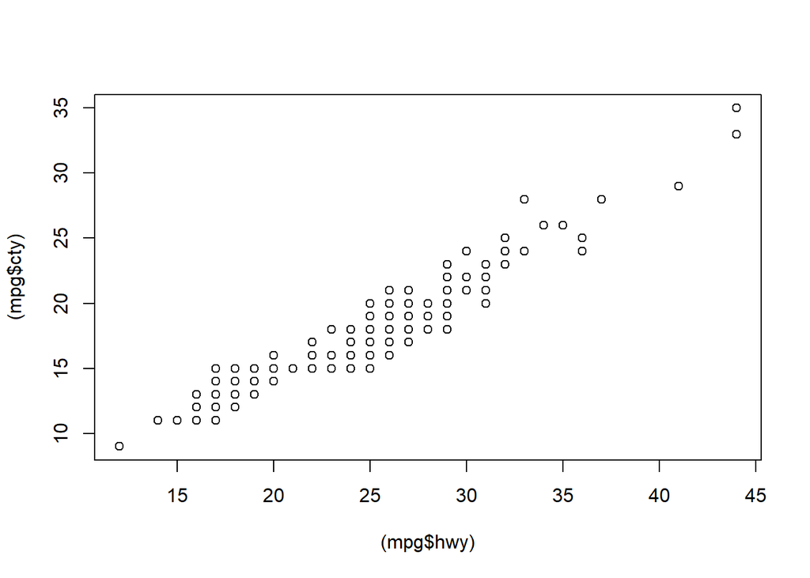

```r
plot((mpg$hwy),(mpg$cty))
```

##### There is positive relationship between hwy and cty variables

##### Plots refere to the types of cars in which some cars have the same value

## Question 4

Are cars in 2008 more fuel efficient than cars in 1999? Use graphs and summary statistics to answer this question.

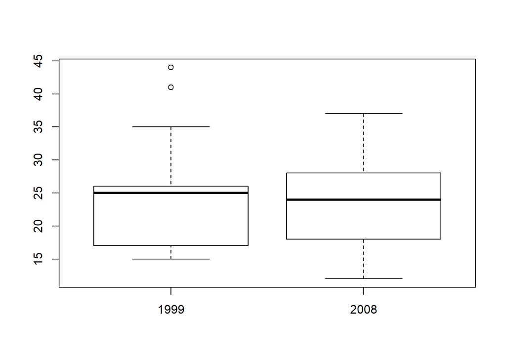

```r
dathwy <- mpg$hwy

box<- boxplot((dathwy[mpg$year==1999]),(dathwy[mpg$year==2008]),names=c("1999","2008"))
```

```r
h99 <- dathwy[mpg$year==1999]
h08 <- dathwy[mpg$year==2008]
summary (h99)
```

```
##    Min. 1st Qu.  Median    Mean 3rd Qu.    Max.
##   15.00   17.00   25.00   23.43   26.00   44.00
```

```r
summary (h08)
```

```
##    Min. 1st Qu.  Median    Mean 3rd Qu.    Max.
##   12.00   18.00   24.00   23.45   28.00   37.00
```